# Assignment 3

Date: November 7, 2023

Notice:

- Due date: 11:59 p.m., November 21, 2023.
- Please submit your solutions on Canvas.
- Two files are required on submission:
  - A **.pdf** file that includes all the conceptual parts. You may take photos of your handwriting hardcopy and compile them into a **.pdf** file.
  - An **.html**/**.pdf** file automatically generated by **.ipynb/.Rmd** file that includes all the codes and results for the coding part. You will get 0 marks in this part if you do not meet the format requirement.
  - The raw **.ipynb/.Rmd** file is **optional**.
  - Write your code in a modular, readable way. Code organization will be taken into account for the grading.

## Exercises from the reference book

Chapter 6: 1, 2, 3, 4, 7.

**Please ensure you are using the second edition of the book, which can be downloaded [here](https://www.statlearning.com/).**

## Coding tasks for logistic regression with $L_2$ penalty

### Description

Suppose that a classification dataset $\{y_i, x_{ij}: i = 1, \dots ,n; j = 1, \dots ,p\}$ is observed, where $x_{ij}$ is the $j$-th predictor of the $i$-th sample and $y_i\in\{0,1\}$ denotes the observed label of $i$-th sample label. The loss function of logistic regression with $L_2$ penalty is defined as $$ -\left[\sum_i^n y_i \log \pi_i+\left(1-y_i\right) \log \left(1-\pi_i\right)\right]+\lambda \sum_j^p \beta_j^2, $$ where $\pi_i=\sigma\left(\sum_j^p x_{i j} \beta_j\right)$ and $\sigma$ is the sigmoid function.

### Tasks

- Implement the penalized logistic regression with given panelty parameter $\lambda$ using Newton’s Method. To make the convergence efficient and stable, you should put $\lambda$ in decreasing order and use the final estimate of $\beta$ with larger $\lambda$ to initialize the Newton iterations for $\beta$ with smaller $\lambda$ (warm start).
- Fit the penalized logistic regression using the training data from `train.txt` file across the sequence of penalty parameter $\lambda$ provided in the `lambda.txt` file. In `train.txt`, there are $100$ rows corresponding to samples, column $y$ is the response vector, columns $X_1, \dots , X_{20}$ are predictors.
- With your fitted models, construct two solution path figures using $\log_{10}\lambda$ and $\left\| \hat{\beta}(\lambda) \right\|_2/ \max \left( \left\|\hat{\beta}(\lambda)\right\|_2 \right)$ as x-axis, respectively. (Your results should be similar to “solution path a” and “solution path b” shown below).
- Given a test dataset $\{y^t_i, x^t_{ij}: i = 1, \dots ,n_\text{test}; j = 1, \dots ,p\}$. The prediction performance of the model with penalty parameter $\lambda$ can be evaluated by the predictive log-likelihood defined as $$\sum_i^{n_\text{test}}y^t_i\log\hat{\pi}_i(\lambda)+(1-y^t_i)\log(1-\hat{\pi}_i(\lambda)),$$ where $\hat{\pi}_i=\sigma(\sum_j^px_{ij}^t\hat{\beta}_j(\lambda))$ and $\hat{\beta}_j(\lambda)$ is the estimate of $\beta_j$ obtained with a given $\lambda$ value. In cross validation, we randomly split our training data into $K$ folds with $\mathcal{F}_1\cup\mathcal{F}_2\cup \dots \cup\mathcal{F}_K=\{1, \dots ,n\}$. Now for each $k = 1, \dots ,K$ and each $\lambda$, we fit the model with all samples but those from $\mathcal{F}_k$ and generate $\hat{\pi}_{-k}(\lambda)$. Then, the predictive likelihood of each fold is given as $$\mathcal{L}(\lambda)=\sum_{i\in\mathcal{F}_k}y_i\log\hat{\pi}_{-k}(\lambda)+(1-y_i)\log(1-\hat{\pi}_{-k}(\lambda)).$$ We can estimate the predictive likelihood by averaging across $K$ folds: $$\hat{\mathcal{L}}(\lambda)=\frac{1}{K}\sum_k^K\mathcal{L}_k(\lambda),$$ and the standard error of $\hat{\mathcal{L}}(\lambda)$ is estimated as $$\text{s.e.}(\hat{\mathcal{L}})=\frac{1}{\sqrt{K}}sd\{\mathcal{L}_1(\lambda), \dots ,\mathcal{L}_K(\lambda)\}.$$ Implement a 10-fold cross validation to assess the model perfomance by evaluating $\hat{\mathcal{L}}(\lambda)$ and $\text{s.e.}(\hat{\mathcal{L}}(\lambda))$ across the provided $\lambda$’s and visulize the trend. The result should be similar to the “10-fold cv” figure shown below.

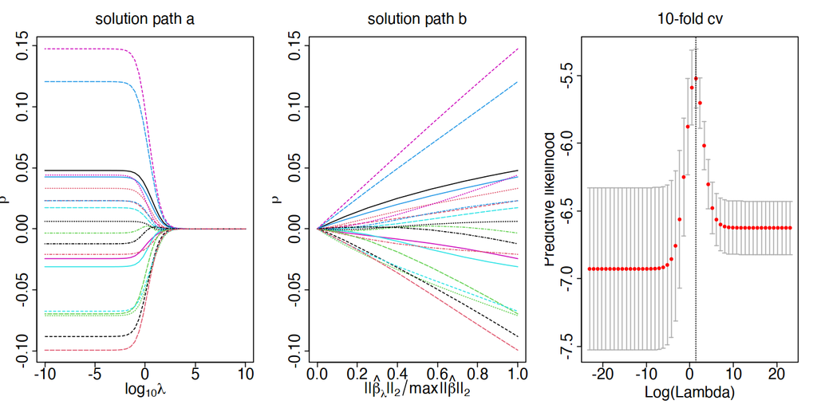